# 1. 좌표계란?

- 좌표계는 하나 이상의 숫자 또는 좌표를 사용하여 유클리드 공간과 같은 다양체에서 점 또는 기타 기하학적 요소의 위치를 고유하게 결정하는 시스템
- 가장 단순한 좌표계는 직교 좌표(카테시안 좌표계)로 알려진 서로 수직으로 향한 좌표축

# 2. coord_cartesian 함수

- ggplot2에서는 coord_catesian 함수를 통해 데카르트 좌표계의 X, Y 축을 변경할 수 있으며 xlim, ylim, expand 세가지 인자를 가지고 있음

## 1) xlim, ylim

- x축과 y축의 범위를 제한할 때 사용
- x축과 y축에 들어가는 데이터를 제한하는 것이 아니라 돋보기를 쓰고 축을 확대하는 개념

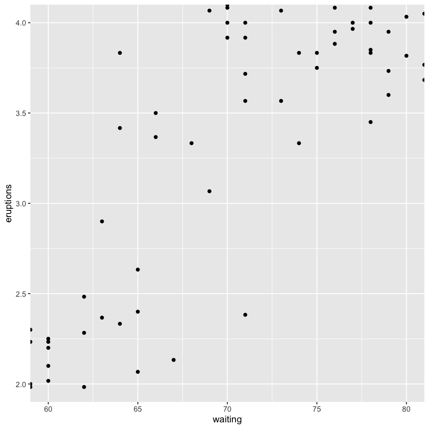

```r
library(ggplot2)
ggplot(faithful, aes(waiting, eruptions)) +
    geom_point() +
    coord_cartesian(xlim = c(60, 80), ylim = c(2:4))
```

- 절대값(직접 숫자 지정)을 지정하여 범위를 제한할 수도 있지만 아래와 같이 상대값(min, max)을 활용하여 지정해 줄 수 도 있음

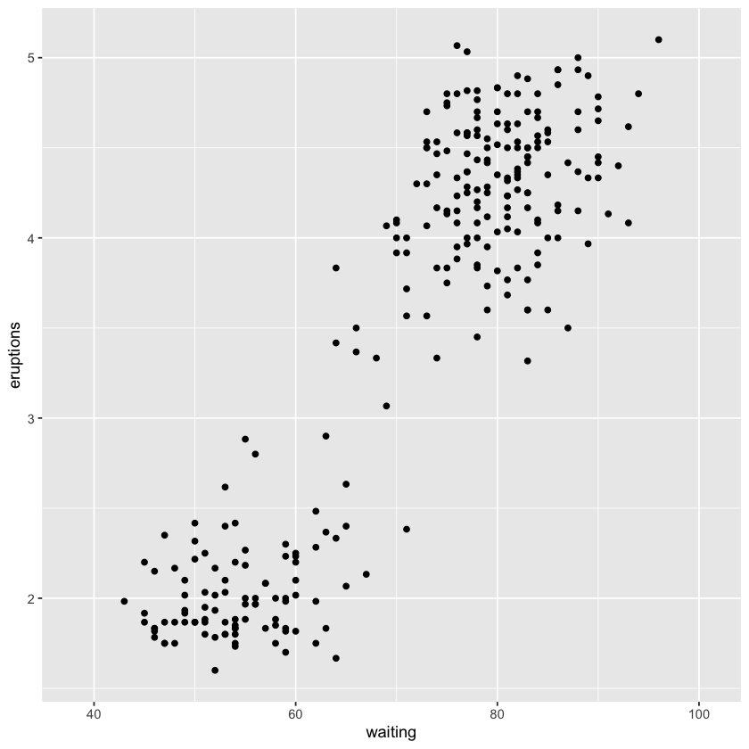

```r
ggplot(faithful, aes(waiting, eruptions)) +
    geom_point() +
    coord_cartesian(xlim = c(min(faithful$waiting) - 5, max(faithful$waiting) + 5))
```

## 2) expand

- 축과 데이터의 겹침을 방지하여 데이터를 플롯에 온전히 표기하기 위해 약간의 여백을 주는 인자
- 디폴트값은 TRUE로 설정되어 있으며 FALSE로 설정 시 그래프의 여백이 사라지게 됨

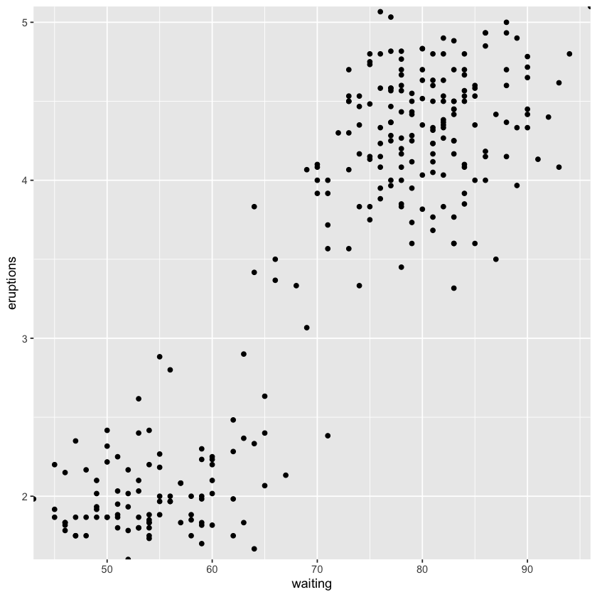

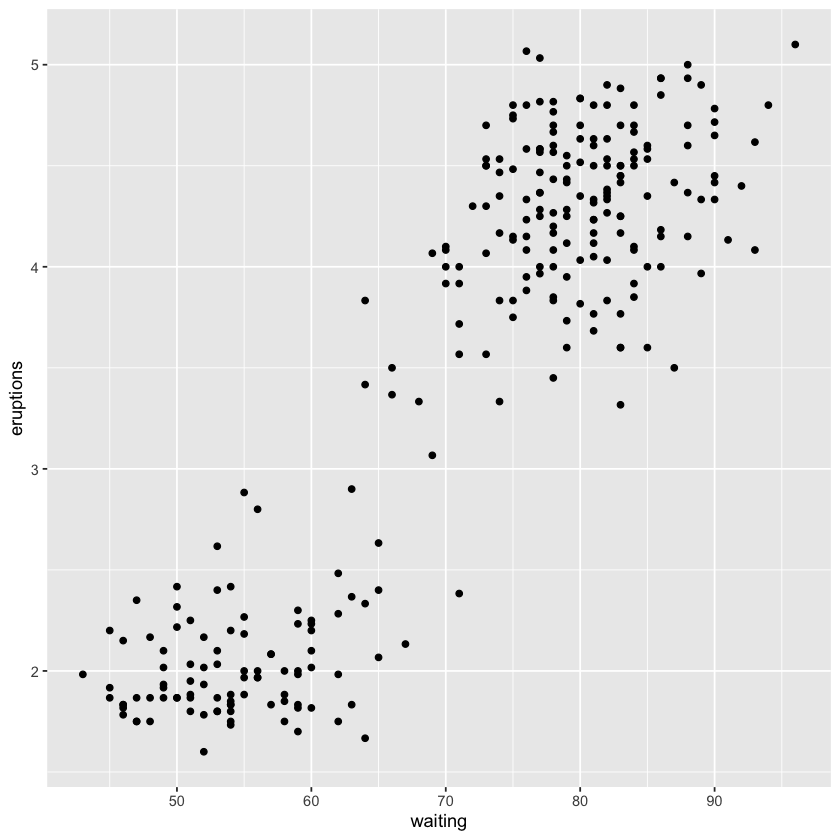

```r
ggplot(faithful, aes(waiting, eruptions)) +
    geom_point() +
    coord_cartesian(expand = FALSE)

ggplot(faithful, aes(waiting, eruptions)) +
    geom_point() +
    coord_cartesian(expand = TRUE)
```

# 3. scale_x_continuous와 차이점

- ggplot2에서 축을 설정하는 함수는 scale_x_continuous, xlim 등 여러가지가 있음
- coord_cartesian은 데카르트 좌표계를 설정
- 그래서 coord_cartesian 함수를 사용하여 x와 y값을 지정하면 단순히 출력되는 좌표계의 범위를 지정하는 것을 의미
- 그러나 scale_x_continuous에서 limit으로 수정하거나 xlim을 사용하면 지정 범위 밖에 있는 데이터를 관측에서 제외함
- coord_cartesian 함수를 사용하여 x축의 범위를 지정함
- 단순히 좌표축을 확대한 것에 불가하기에 히스토그램의 모양이 잡아 당긴 것처럼 변형
- 그리고 faithful 전체 데이터를 대상으로 하기 때문에 최대값이 6으로 지정

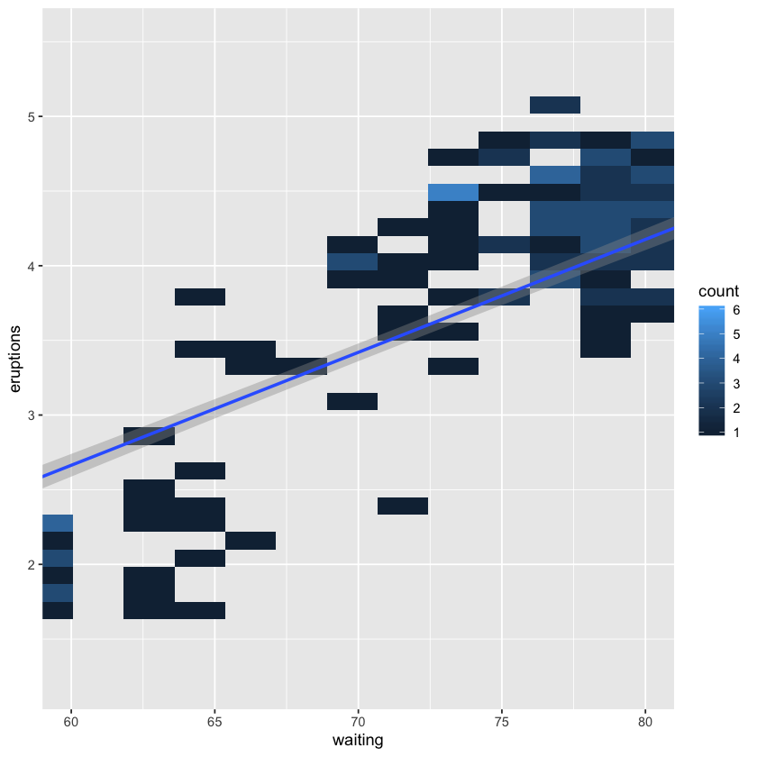

```r
ggplot(faithful, aes(waiting, eruptions)) +
    geom_bin2d() +
    coord_cartesian(xlim = c(60, 80)) +
    geom_smooth(method = lm)
```

- scale_x_continuous를 사용한 두 번째 그래프를 보면 확연한 차이를 보임
- 지정한 x축 범위를 초과하는 값은 계산에서 배제되어 히스토그램의 모양이 온전해짐
- 또한 범위에 속해있는 데이터만 분석하기 때문에 count의 최대값이 3에 머물러 있음
- 단순히 그래프의 축을 확대하려면 coord_cartesian 함수를 사용하면 되지만, 그래프의 출력되는 데이터 자체를 수정하려면 scale_x_continous 함수를 사용하면 됨

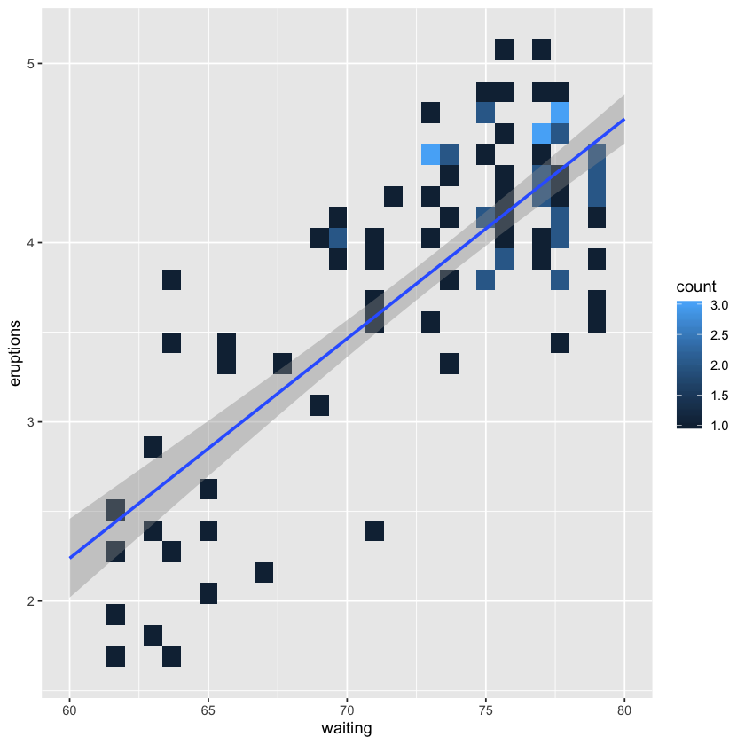

```r
ggplot(faithful, aes(waiting, eruptions)) +
    geom_bin2d() +
    scale_x_continuous(limits = c(60, 80)) +
    geom_smooth(method = lm)
```